# **Panorama da inflação**

Os principais índices de inflação do Brasil, apontam em setembro de 2012 um avanço da inflação de em média **0.72%**. Com esse resultado, no ano a inflação acumula uma variação média positiva de **4.90%**, e em 12 meses uma variação média acumulada de **6.31%**.

[output not shown]

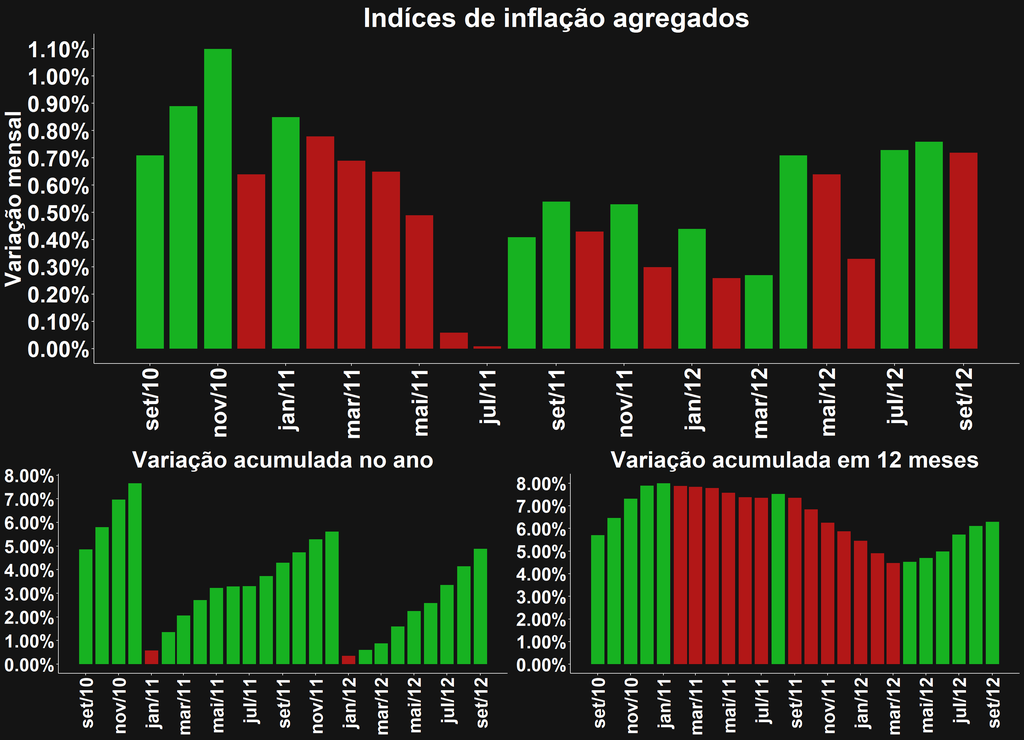

Índices selecionados para a média: IPCA, INPC e IGP-M.

# IPCA

O Indíce de Preços ao Consumidor Amplo (IPCA) variou 0.57% em setembro, valor superior ao mesmo período do ano anterior quando apresentou uma taxa de 0.53%. Com esse resultado o indíce acumula no ano uma variação positiva de 3.77%, e em 12 meses uma variação positiva de 5.28%.

|  | 09/2011 | 08/2012 | 09/2012 |
| --- | --- | --- | --- |
| Variação mensal | 0.53% | 0.41% | 0.57% |
| Variação acumulada no ano | 4.97% | 3.18% | 3.77% |
| Variação acumulada em 12 meses | 7.31% | 5.24% | 5.28% |

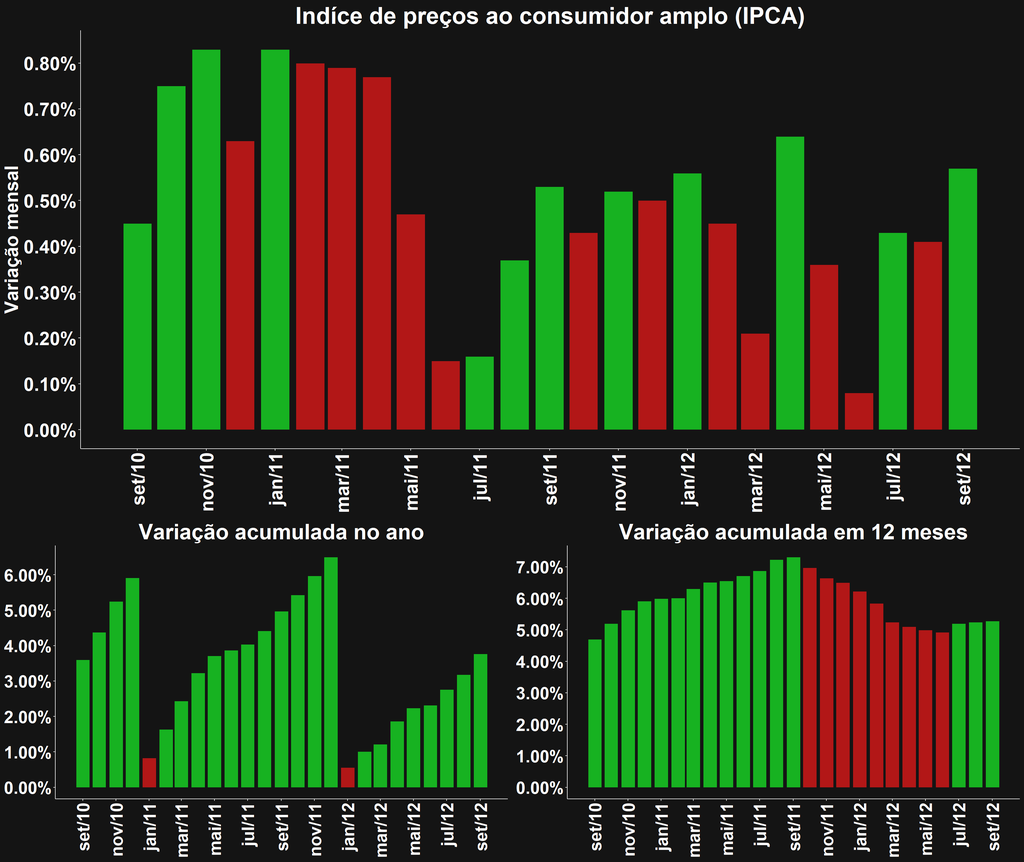

|  | Variação mensal | Variação acumulada no ano | Peso mensal |
| --- | --- | --- | --- |
| Alimentação e bebidas | 1.26% | 6.44% | 23.55% |
| Habitação | 0.71% | 5.07% | 14.78% |
| Artigos de residência | 0.18% | -0.26% | 4.51% |
| Vestuário | 0.89% | 2.63% | 6.57% |
| Transportes | -0.08% | -1.19% | 19.7% |
| Saúde e cuidados pessoais | 0.32% | 4.68% | 11.22% |
| Despesas pessoais | 0.73% | 7.74% | 10.31% |
| Educação | 0.1% | 7.48% | 4.55% |
| Comunicação | 0.03% | 0.11% | 4.81% |

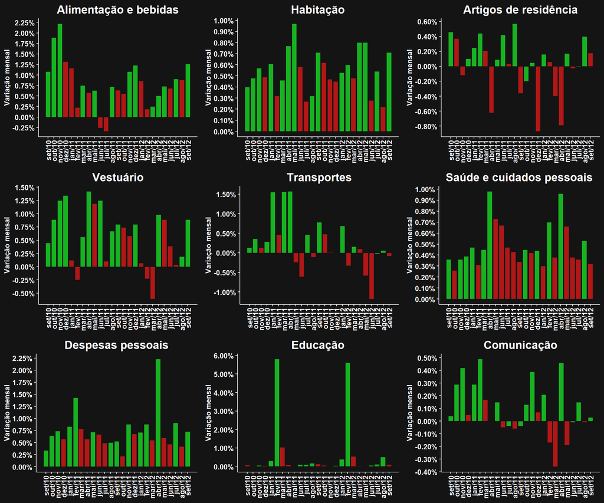

A nível de sub-itens os que mais influenciaram positivamente no resultado em relação ao seu peso foram Empregado doméstico (1.24%%) e Arroz (8.21%%), e negativamente Tomate (-12.88%%) e Automóvel usado (-1.62%%).

|  | Variação mensal | Variação acumulada no ano | Peso mensal |
| --- | --- | --- | --- |
| Arroz | 8.21% | 18.13% | 0.53% |
| Batata-inglesa | 21.61% | 49.24% | 0.17% |
| Empregado doméstico | 1.24% | 11.27% | 3.74% |
| Refeição | 0.74% | 6.11% | 4.9% |

|  | Variação mensal | Variação acumulada no ano | Peso mensal |
| --- | --- | --- | --- |
| Conserto de automóvel | -0.55% | 3.87% | 1.72% |
| Lanche | -1% | 5.9% | 1.81% |
| Automóvel usado | -1.62% | -10.11% | 1.53% |
| Tomate | -12.88% | 53.74% | 0.36% |

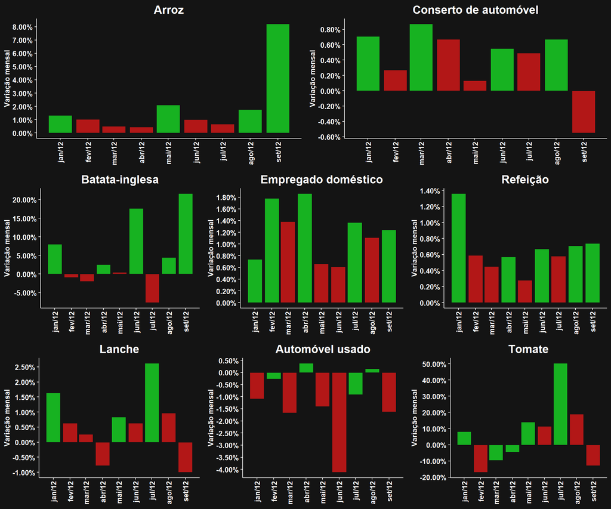

# INPC

O Indíce Nacional de Preços ao Consumidor (INPC) variou 0.63% em setembro, valor superior ao mesmo período do ano anterior quando apresentou uma taxa de 0.45%. Com esse resultado o indíce acumula no ano uma variação positiva de 4.11%, e em 12 meses uma variação positiva de 5.58%.

|  | 09/2011 | 08/2012 | 09/2012 |
| --- | --- | --- | --- |
| Variação mensal | 0.45% | 0.45% | 0.63% |
| Variação acumulada no ano | 4.61% | 3.46% | 4.11% |
| Variação acumulada em 12 meses | 7.3% | 5.39% | 5.58% |

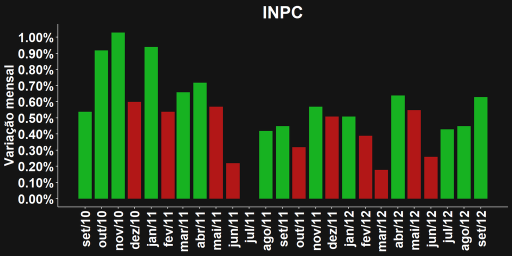

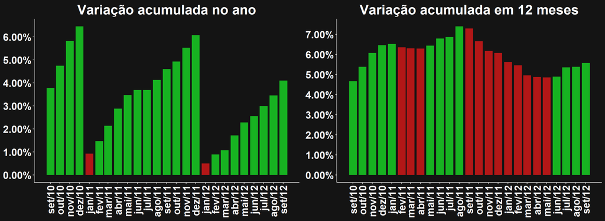

# IGP-M

O Indíce Geral de Preços de Mercado (IGP-M) variou 0.97% em setembro, valor superior ao mesmo período do ano anterior quando apresentou uma taxa de 0.65%. Com esse resultado o indíce acumula no ano uma variação positiva de 6.82%, e em 12 meses uma variação positiva de 8.07%.

|  | 09/2011 | 08/2012 | 09/2012 |
| --- | --- | --- | --- |
| Variação mensal | 0.65% | 1.43% | 0.97% |
| Variação acumulada no ano | 3.33% | 5.8% | 6.82% |
| Variação acumulada em 12 meses | 7.46% | 7.72% | 8.07% |

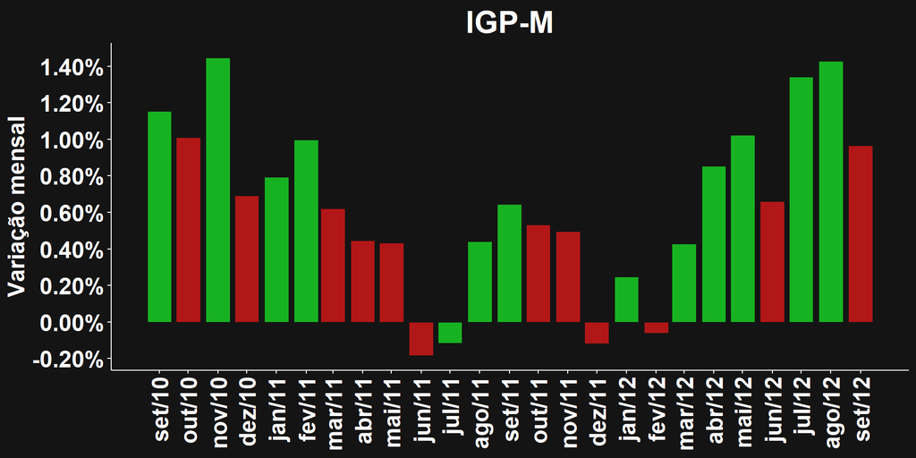

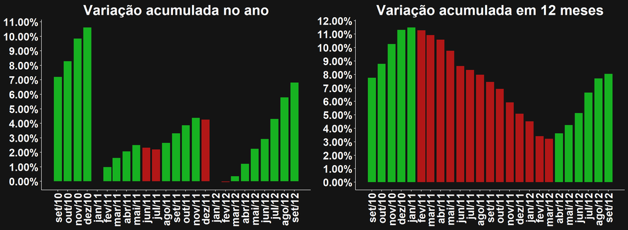

# IGP-DI

O Indíce Geral de Preços - Disponibilidade Interna (IGP-DI) variou 0.88% em setembro, valor superior ao mesmo período do ano anterior quando apresentou uma taxa de 0.75%. Com esse resultado o indíce acumula no ano uma variação positiva de 7.14%, e em 12 meses uma variação positiva de 8.17%.

|  | 09/2011 | 08/2012 | 09/2012 |
| --- | --- | --- | --- |
| Variação mensal | 0.75% | 1.29% | 0.88% |
| Variação acumulada no ano | 3.29% | 6.2% | 7.14% |
| Variação acumulada em 12 meses | 7.45% | 8.04% | 8.17% |

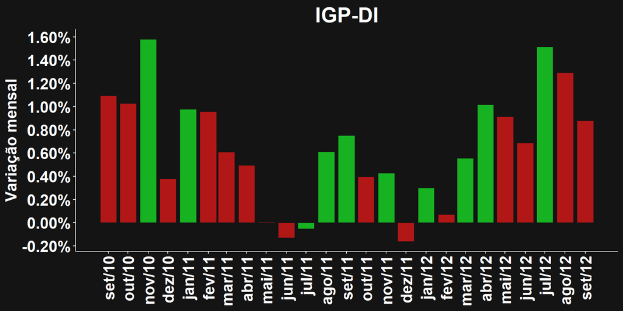

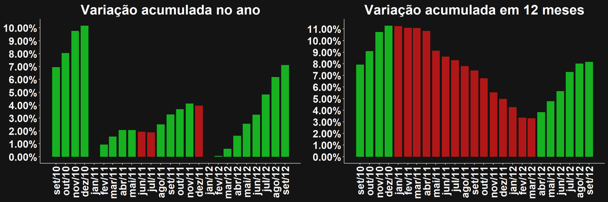

[output not shown]

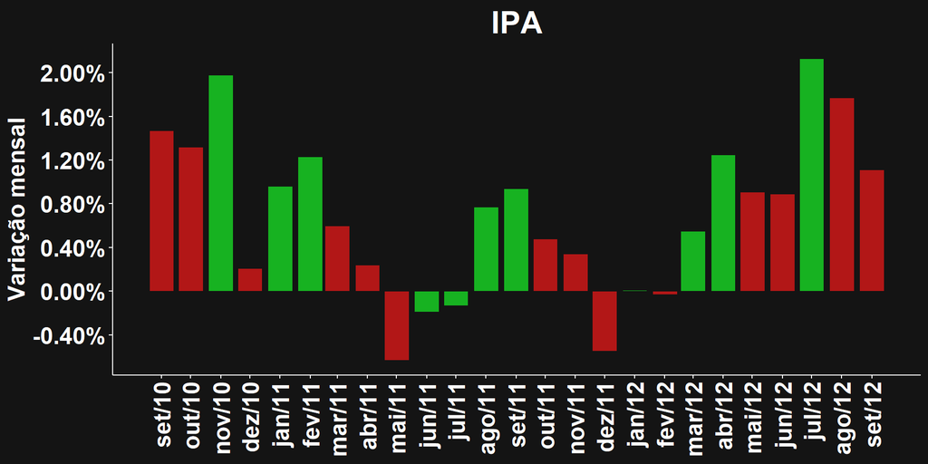

[figure not shown]

O Indíce de Preços ao Consumidor (IPC), integrante do IGP-DI com peso de 30%, apresentou variação de 0.54% em setembro, valor superior ao mesmo período do ano anterior quando apresentou uma taxa de 0.5%. Com esse resultado o indíce acumula no ano uma variação positiva de 3.23%, e em 12 meses uma variação positiva de 5.73%.

|  | 09/2011 | 08/2012 | 09/2012 |
| --- | --- | --- | --- |
| Variação mensal | 0.5% | 0.44% | 0.54% |
| Variação acumulada no ano | 3.38% | 2.68% | 3.23% |
| Variação acumulada em 12 meses | 7.13% | 5.69% | 5.73% |

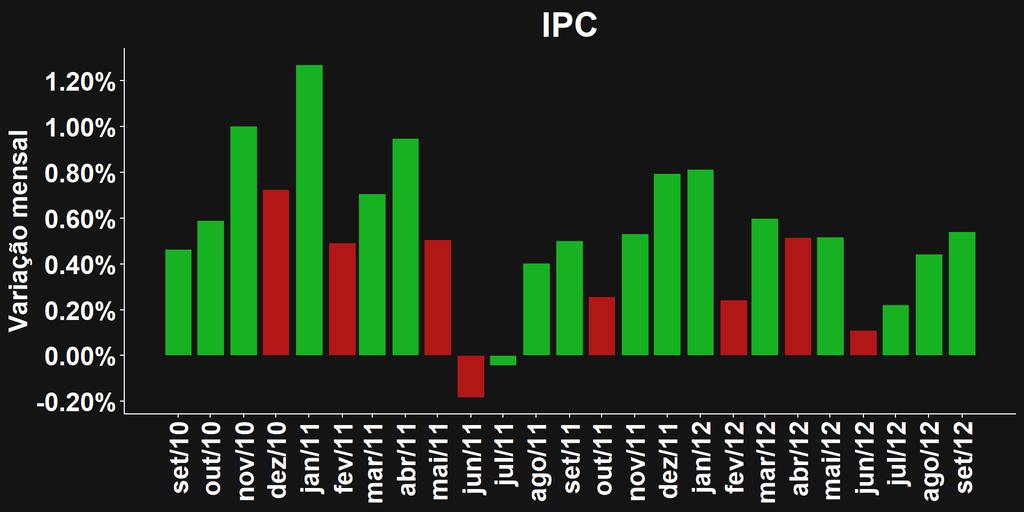

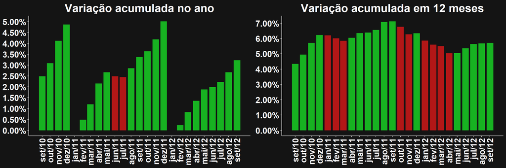

O Indíce Nacional de Custos de Construção (INCC), integrante do IGP-DI com peso de 10%, apresentou variação de 0.22% em setembro, valor superior ao mesmo período do ano anterior quando apresentou uma taxa de 0.14%. Com esse resultado o indíce acumula no ano uma variação positiva de 5.43%, e em 12 meses uma variação positiva de 7.49%.

|  | 09/2011 | 08/2012 | 09/2012 |
| --- | --- | --- | --- |
| Variação mensal | 0.14% | 0.26% | 0.22% |
| Variação acumulada no ano | 5.93% | 5.19% | 5.43% |
| Variação acumulada em 12 meses | 7.68% | 7.41% | 7.49% |

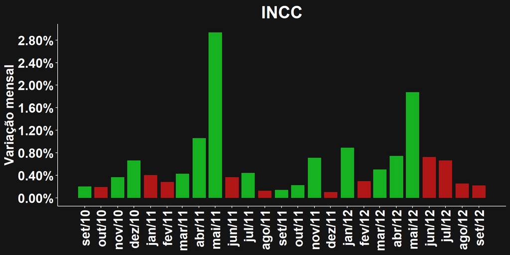

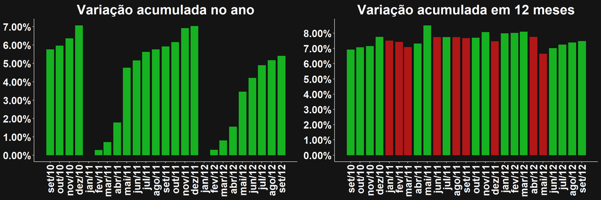

# Estatísticas

As estatísticas descritivas a seguir são feitas com base nos últimos 48 meses, e tem como objetivo possibilitar a avaliação do resultado observado em comparação aos períodos anteriores.

|  | Minimo | 1 Quartil | Mediana | Media | 3 Quartil | Maximo | Desvio Padrão |
| --- | --- | --- | --- | --- | --- | --- | --- |
| IPCA | 0% | 0.28% | 0.45% | 0.44% | 0.56% | 0.83% | 0.22% |
| INPC | -0.11% | 0.26% | 0.45% | 0.45% | 0.61% | 1.03% | 0.26% |
| IGP-M | -0.74% | -0.06% | 0.47% | 0.46% | 0.88% | 1.45% | 0.55% |
| IGP-DI | -0.84% | 0.04% | 0.41% | 0.46% | 0.96% | 1.58% | 0.58% |
| IPA | -1.46% | -0.11% | 0.38% | 0.46% | 1% | 2.13% | 0.85% |
| IPC | -0.21% | 0.22% | 0.48% | 0.45% | 0.63% | 1.29% | 0.34% |
| INCC | -0.26% | 0.2% | 0.37% | 0.53% | 0.72% | 2.94% | 0.56% |

Levando em consideração o desvio padrão de cada indíce, proporcionalmente os que mais se afastaram da média foram o IGP-M, o IPA e o IGP-DI.

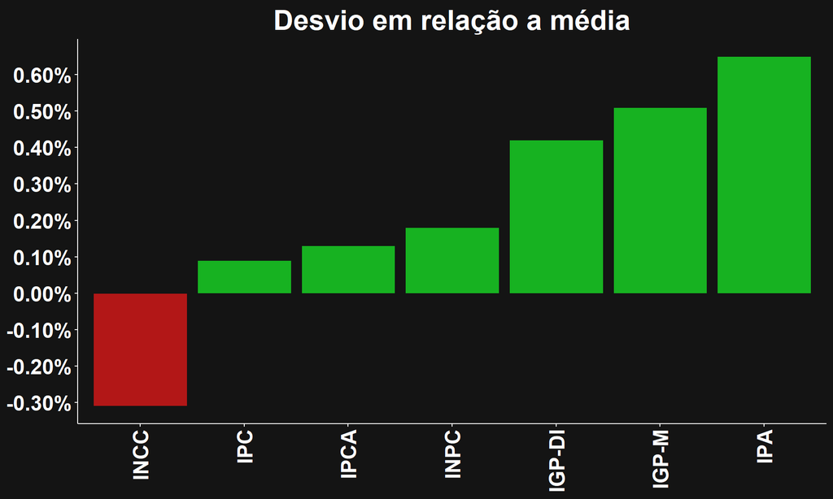

**João Victor Gomes**  
**jvg.santana@gmail.com**  
**[linkedin.com/in/jvictorgomes](https://www.linkedin.com/in/jvictorgomes/)**